# Script10_Armbruster2026_PeripheralSubset

Daniel Armbruster

2026-07-24

- In this script we subset the neuroeptihelial (NEC) and peripheral neurons (PN) cluster from the whole dataset presented in Figure 1C and performed a standard clustering workflow followed by annotation and differentially expressed gene analysis. The differentially expressed genes per cluster are given in S4.
- In addition, this script generated the plots presented in Figure 4A-E.
- The session info including the used packages and their versions is provided at the end of this script.

# 1. Load packages

```r
library(Seurat)
library(dplyr)
library(openxlsx)
library(tidyverse)
library(cowplot)
```

# 2. Load Data

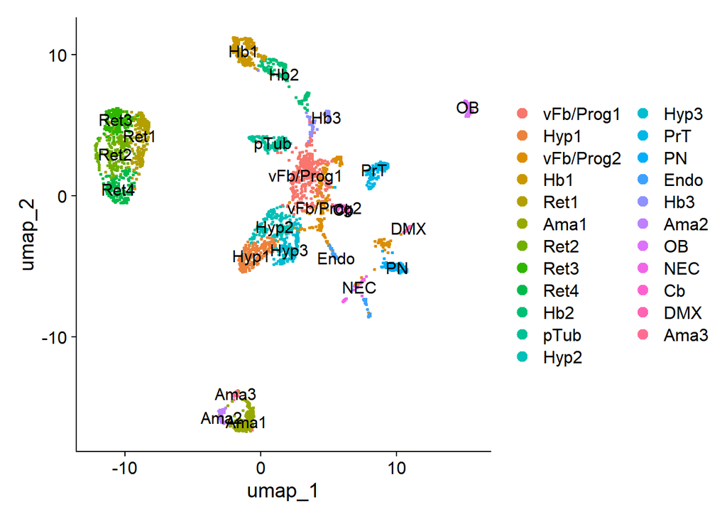

```r
normalized_cells_clustered <- readRDS(file = "RDS_files/Script3_Armbruster2026_annotated.rds")

DimPlot(normalized_cells_clustered, label = T)
```

# 3. Subsetting of peripheral NA neurons

```r
Peripheral_subset <- subset(normalized_cells_clustered, idents = c("NEC", "PN"))
```

# 4. Standard workflow and clustering

```r
DefaultAssay(Peripheral_subset) <- "RNA"
Peripheral_subset <- FindVariableFeatures(Peripheral_subset, selection.method = "vst", nfeatures = 2000, verbose = FALSE)
Peripheral_subset <- ScaleData(Peripheral_subset)
Peripheral_subset <- RunPCA(Peripheral_subset)
```

```
## PC_ 1
## Positive:  si:dkey-85n7.8, ca2, ndufa4l2a, dgkzb, slc26a3.2, atp1a3b, epas1a, higd1a, hs3st3b1b, rgs5a
##     zgc:153157, si:dkey-1h6.8, si:ch73-62b13.1, rprma, tcf7l2, tcf12, dgkza, fam162a, reck, insm1a
##     trpc7a, arpp21, dlg2, CABZ01085140.1, ltb4r2a, zgc:153704, sass6, rgs4, myo1hb, si:ch211-151p13.8
## Negative:  tubb5, stmn1b, tuba1a, stmn2b, mab21l2, ppp1r1c, vim, stmn4l, grm4, si:dkeyp-77h1.4
##     itga1, ptprt, sox11a, slc6a2, si:dkey-56m19.5, il13ra2, scn1a, cnp, CR848841.1, fxyd6
##     adcyap1r1a, CABZ01069081.1, tubb4b, mao, socs3b, b3gnt7, hoxb8a, foxo3b, ppp1r14ba, tagln2
## PC_ 2
## Positive:  ca2, trpc7a, si:dkey-1h6.8, slc26a3.2, kcnj3a, pth1ra, nt5dc3, vsnl1a, si:ch73-62b13.1, dgkzb
##     tcf7l2, syne1b, rasl12, adgra2, ltb4r2a, arpp21, si:dkey-85n7.8, fzd8a, zgc:153157, slc5a7a
##     sncgb, kitlga, dlg2, rprma, tmem263, si:ch211-257p13.3, BX088707.3, slc6a2, rapgef4, sostdc1a
## Negative:  sepw2b, capsla, acsl1b, foxj1a, pnocb, apln, tctex1d2, tescb, tbc1d1, dlx3b
##     npb, nrg2a, dtnba, dnal1, slc35b2, FO904881.1, ENSDARG00000063672, efr3ba, si:ch211-117k10.3, mettl7a
##     echdc2, pvalb5, zgc:101731, pax7a, cobl, flvcr2b, gstp1, hspb6, CCDC189, dnai2b
## PC_ 3
## Positive:  pax7a, oacyl, hspb6, odc1, aldh1a3, pomca, AL590149.1, slc24a4a, sema3ab, fgf8a
##     trhde.1, zgc:101744, sqlea, rdh10a, six3b, grp, col19a1.1, crabp1a, pitx3, vax1
##     ap1s3b, ascl1a, serpinh1b, tagapa, slc1a6, scg3, rcn3, col19a1, fam46ab, syngr2b
## Negative:  si:ch211-117k10.3, echdc2, flvcr2b, BX088547.2, erich3, fuom, cgrrf1, pvalb5, rassf4, ethe1
##     zgc:109949, cabp1a, npb, guk1a, si:dkey-48g21.6, ak8, tescb, acp2, zgc:92249, gpr158a
##     stmn1b, msl1a, tbc1d1, nim1k, rcbtb1, zgc:101731, gng13b, elac1, si:ch211-209l18.2, mob1ba
## PC_ 4
## Positive:  tubb5, stmn2b, vim, rplp1, stmn1b, cnp, herpud1, phactr2, tuba1a, hspb6
##     aldh1a3, nos1apa.1, ENSDARG00000008491, fgf8a, zgc:101744, sqlea, rps17, tubb4b, traf3ip2b, ubxn7
##     eef1b2, odc1, sox11a, rps12, pitx3, ap1s3b, oacyl, six3b, col19a1.1, pax7a
## Negative:  mdka, phex, atp2b2, ptn, si:ch211-1a19.3, meis1a, TCIM, jdp2b, cldnh, fosb
##     aqp3a, tfap2c, ralyl, si:ch1073-443f11.2, f11r.1, ela3l, col12a1b, si:ch211-152c2.3, p3h2, rgs5a
##     myh9a, tnnt2a, frzb, si:ch211-199g17.2, lrrfip1a, fam49a, gramd2aa, nr4a1, sik1, FP236545.1
## PC_ 5
## Positive:  mtbp, csmd2, gria4b, fam19a1a, ldb2b, ppfibp1b, anos1a, pax6b, mtus1a, ms4a17a.9
##     hs3st1l2, ppp4r2b, gpd1b, ncam2, si:dkey-219c3.2, zmat4a, col4a4, gad1b, tiam1a, cemip
##     elovl5, hapln1b, themis2, CU550716.2, BX324216.5, grin1a, si:ch211-196g2.4, pappab, gria2b, slc38a3a
## Negative:  nt5dc3, si:ch73-62b13.1, ENSDARG00000074560, carhsp1, si:ch211-151p13.8, tnnt2d, hsd11b2, si:ch211-67e16.11, si:dkey-282h22.5, ctbp2a
##     ethe1, slc6a4a, tshz3a, dlx3b, rasl12, depdc7, si:ch211-194e15.5, ENSDARG00000075629, glod5, dnal1
##     zgc:64022, ccdc28a, adgra2, kifc3, klhl10b.1, sps2, sostdc1a, si:ch73-359m17.7, si:dkey-199f5.8, TMEM114
```

```r
Peripheral_subset <- FindNeighbors(object = Peripheral_subset,dims = 1:20)
Peripheral_subset <- RunUMAP(Peripheral_subset, dims = 1:20, reduction = "pca", seed.use = 42L)
Peripheral_subset <- FindClusters(object = Peripheral_subset, resolution = c(0.4))
```

```
## Modularity Optimizer version 1.3.0 by Ludo Waltman and Nees Jan van Eck
##
## Number of nodes: 158
## Number of edges: 5476
##
## Running Louvain algorithm...
## Maximum modularity in 10 random starts: 0.7045
## Number of communities: 2
## Elapsed time: 0 seconds
```

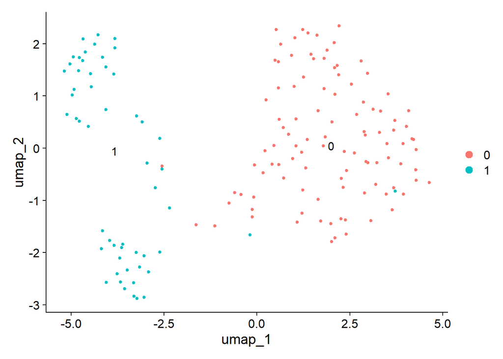

```r
Idents(object = Peripheral_subset) <- "RNA_snn_res.0.4"
DimPlot(Peripheral_subset, label = T)
```

# 5. Annotation

- As we were unable to resolve further biological identities, beyond distinguishing peripheral neurons (PN) and neuroepithelial cells (NEC) in this subset, we decided to focus on the DEG comparison between these two cell classes.
- Prior to annotation we performed DEG analysis (not included in this script) to identify cluster-specific genes. Using these results together with literature research we assigned the cluster identities.
- After annotation we repeated DEG analysis (see section 6) to generate the marker gene table, provided in Supplementary Table 4 of the manuscript, with annotated cluster names.

## 5.2 Peripheral NA Neurons

- Peripherin (prph) is expressed broadly in peripheral neurons (Escurat et al., 1990)
- Label: cl0 = PN

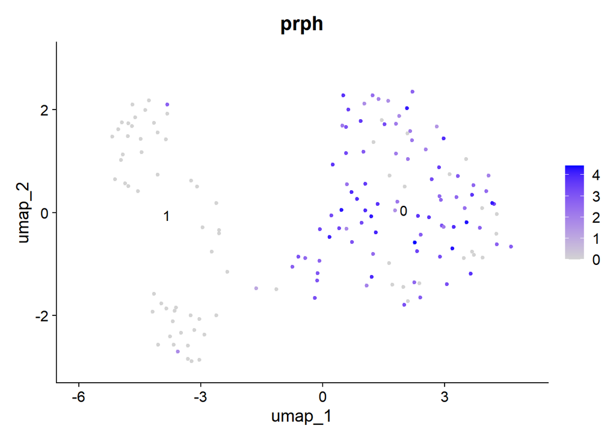

```r
FeaturePlot(Peripheral_subset, "prph", label=T)
```

## 5.3 Neuroepithelial NA cells

- Cluster 1 shows enriched expression of si:dkey-85n7.8, ca2, epas1a, ndufa4l2a
- epas1a and ndufa4l2a was also described to be expressed along genes such as rgs5a, tph1a and sv2a in the catecholaminergic neuroepithelial cells (NECs) of the zebrafish gills (Pan et al., 2022; DOI: 10.1038/s41598-022-13693-1)
- As these genes detected by Pan and colleagues are also expressed by cells of cluster 1, it is likely that it consists at least partially of gill NECs
- Label: cl1 = NEC

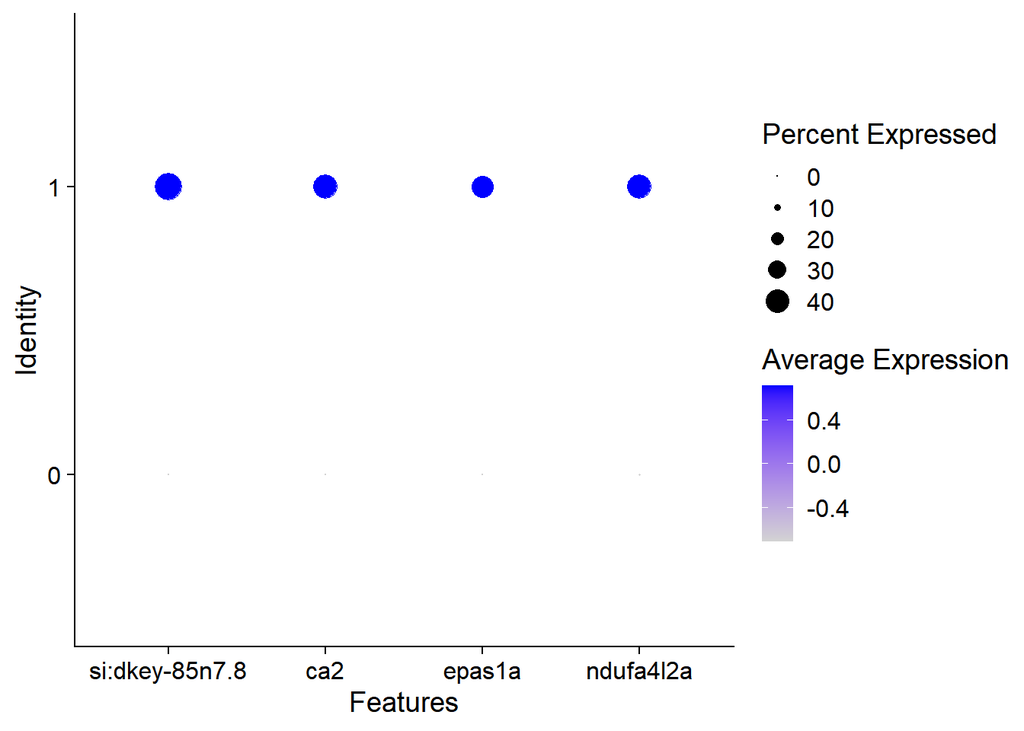

```r
DotPlot(Peripheral_subset, features = c("si:dkey-85n7.8", "ca2", "epas1a", "ndufa4l2a"))
```

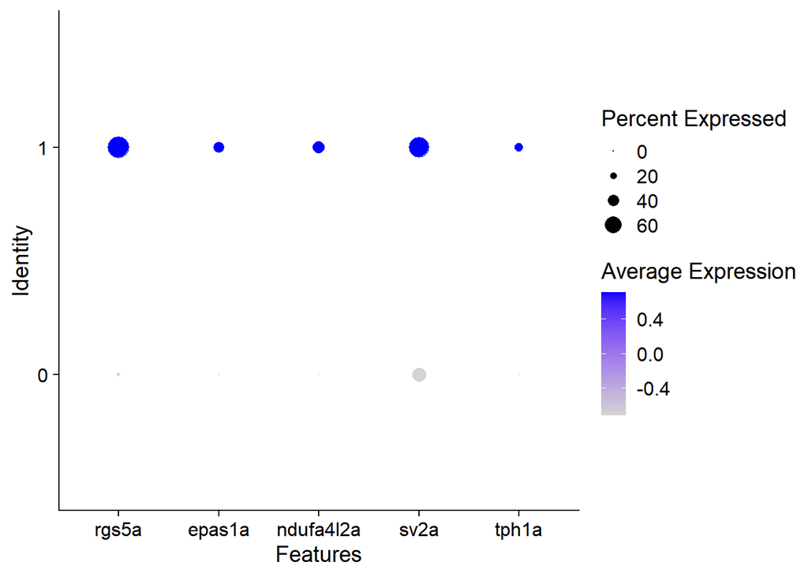

```r
DotPlot(Peripheral_subset, features = c("rgs5a", "epas1a", "ndufa4l2a","sv2a", "tph1a"))
```

## 5.4 Annotating the data

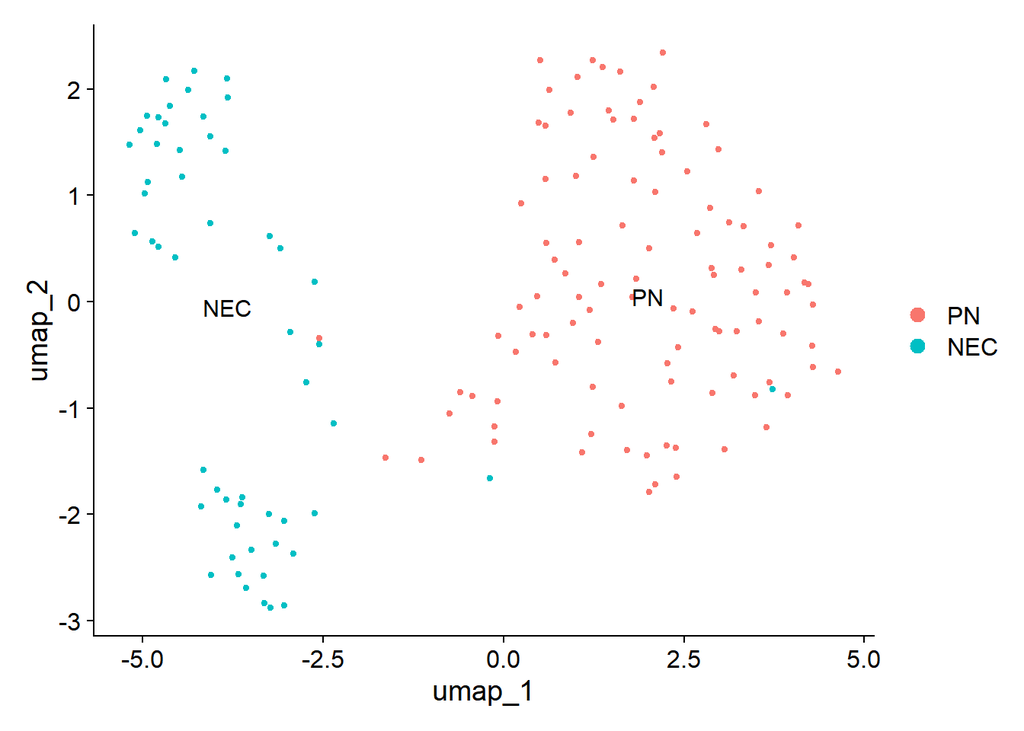

```r
Peripheral_subset <- RenameIdents(object = Peripheral_subset, "0" = "PN", "1"= "NEC")

DimPlot(Peripheral_subset, label = T)
```

```r
Peripheral_subset$Peripheral_Fig_annotation <- Peripheral_subset@active.ident
```

# 6. DEG Analysis of annotated Seurat object

```r
###################################################################################
# Calculate DEGs and generate dataframes for all DEGs and TF DEGs
norm_markers <- FindAllMarkers(Peripheral_subset, only.pos = TRUE, min.pct = 0.2, logfc.threshold = .25)
```

[output not shown]

```r
# Only include DEGs with adjusted p-value < 0.05
try(norm_markers <- dplyr::filter(norm_markers, p_val_adj <= 0.05))

# Sort by avg_log2FC
norm_markers_sorted <- norm_markers %>% group_by(cluster) %>% dplyr::arrange(desc(avg_log2FC), .by_group = T)


# Gene as first column
norm_markers_sorted <- norm_markers_sorted %>% relocate(gene, .before = p_val) %>% relocate(cluster, .before = gene)

# Sort for top 50 transcription factor DEGs and save as file
TFlist <- read_tsv(file = "Resources/DanioRerio_TF.tsv")
TFlist$Species <- NULL
TFlist$Ensembl <- NULL
TFlist$Family <- NULL
TFlist$Protein <- NULL
TFlist$`Entrez ID` <- NULL
TFlist <- TFlist[!duplicated(TFlist), ]

names(TFlist)[names(TFlist) == "Symbol"] <- "gene"

TF_markers <- inner_join(norm_markers, TFlist, by = "gene")

# Sort by avg_log2FC
TF_markers_sorted <- TF_markers %>% group_by(cluster) %>% dplyr::arrange(desc(avg_log2FC), .by_group = T)
TF_markers_sorted <- TF_markers_sorted %>% relocate(gene, .before = p_val) %>% relocate(cluster, .before = gene)

###################################################################################
# Get count info about the DEGs for all clusters

# ALL GENES:
#Get sum of norm counts within cluster
norm_markers_sumcounts_per_cluster <- AggregateExpression(
  Peripheral_subset,
  assays   = "RNA",
  slot     = "data",
  features = norm_markers$gene,
  group.by = "Peripheral_Fig_annotation",
  verbose  = FALSE
)
# Get avg of norm counts within cluster
norm_markers_avgcounts_per_cluster <- AverageExpression(
  Peripheral_subset,
  assays   = "RNA",
  slot     = "data",
  features = norm_markers$gene,
  group.by = "Peripheral_Fig_annotation",
  verbose  = FALSE
)
```

```
## As of Seurat v5, we recommend using AggregateExpression to perform pseudo-bulk analysis.
```

```r
# Generate combined df for the count
norm_markers_sumcounts_per_cluster <- as.data.frame(norm_markers_sumcounts_per_cluster)
colnames(norm_markers_sumcounts_per_cluster) <- paste(colnames(norm_markers_sumcounts_per_cluster), "_sum_normcount", sep="")
norm_markers_avgcounts_per_cluster <- as.data.frame(norm_markers_avgcounts_per_cluster)
colnames(norm_markers_avgcounts_per_cluster) <- paste(colnames(norm_markers_avgcounts_per_cluster), "_avg_normcount", sep="")
norm_markers_counts_per_cluster <- cbind(norm_markers_sumcounts_per_cluster, norm_markers_avgcounts_per_cluster)
norm_markers_counts_per_cluster <- norm_markers_counts_per_cluster[, order(colnames(norm_markers_counts_per_cluster))]

# TRANSCRIPTION FACTORS:
#Get sum of normcounts within cluster
TF_markers_sumcounts_per_cluster <- AggregateExpression(
  Peripheral_subset,
  assays   = "RNA",
  slot     = "data",
  features = TF_markers$gene,
  group.by = "Peripheral_Fig_annotation",
  verbose  = FALSE
)
# Get avg of normcounts within cluster
TF_markers_avgcounts_per_cluster <- AverageExpression(
  Peripheral_subset,
  assays   = "RNA",
  slot     = "data",
  features = TF_markers$gene,
  group.by = "Peripheral_Fig_annotation",
  verbose  = FALSE
)

# Generate combined df for the count
TF_markers_sumcounts_per_cluster <- as.data.frame(TF_markers_sumcounts_per_cluster)
colnames(TF_markers_sumcounts_per_cluster) <- paste(colnames(TF_markers_sumcounts_per_cluster), "_sum_normcount", sep="")
TF_markers_avgcounts_per_cluster <- as.data.frame(TF_markers_avgcounts_per_cluster)
colnames(TF_markers_avgcounts_per_cluster) <- paste(colnames(TF_markers_avgcounts_per_cluster), "_avg_normcount", sep="")
TF_markers_counts_per_cluster <- cbind(TF_markers_sumcounts_per_cluster, TF_markers_avgcounts_per_cluster)
TF_markers_counts_per_cluster <- TF_markers_counts_per_cluster[, order(colnames(TF_markers_counts_per_cluster))]

##########################################################################
# Cell number per cluster
n_cells <- FetchData(Peripheral_subset,
                     vars = c("ident", "orig.ident")) %>% dplyr::count(ident, orig.ident) %>% tidyr::spread(ident,n)

n_cells <- as.data.frame(t(n_cells))
n_cells<- n_cells %>% dplyr::filter(row_number() != 1)
n_cells
```

```
##      V1
## PN  104
## NEC  54
```

```r
colnames(n_cells) <- "CellNumber"
n_cells$CellNumber <- as.numeric(n_cells$CellNumber)

n_cells
```

```
##     CellNumber
## PN         104
## NEC         54
```

```r
# Generate xlsx files
dataframe_names <- list("CellNumbers" = n_cells, "All_DEGs" = norm_markers_sorted, "TF_DEGs" = TF_markers_sorted, "All_DEGs_CountInformation" = norm_markers_counts_per_cluster, "TF_DEGs_CountInformation" = TF_markers_counts_per_cluster)



openxlsx::write.xlsx(dataframe_names, file = "DEG_tables/Script10_Peripheral/Script10_Peripheral_DEG_Info.xlsx", rowNames=T)
```

# 7. Save Seurat object with annotations

```r
saveRDS(Peripheral_subset, "RDS_files/Script10_Armbruster_2026_Peripheral.rds")


Peripheral_subset <- readRDS("RDS_files/Script10_Armbruster_2026_Peripheral.rds")
```

# 8. For figure 4

## 8.1 UMAP with cluster annotation

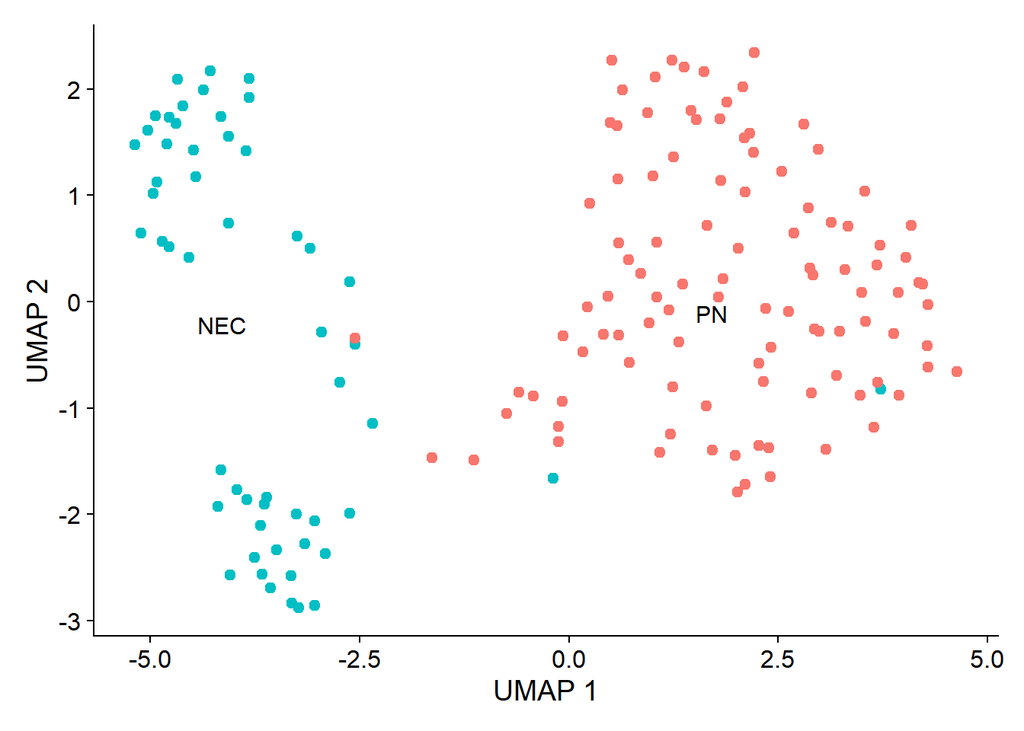

```r
Peripheral_DimPlot <- DimPlot(Peripheral_subset, pt.size = 2, label = T, repel = T) +
  NoLegend() +
  labs(x = "UMAP 1", y = "UMAP 2") +
    theme(
        plot.title = element_text(size = 16, face = "bold"),
    )

Peripheral_DimPlot
```

```r
ggsave("Script10_Fig4Supp_Peripheral_DimPlot.svg", plot = Peripheral_DimPlot, path = "Figures/Figure4_Peripheral/", width = 5, height = 4)
```

## 8.2 FeaturePlots for relevant genes

```
## [1] "hand2"
```

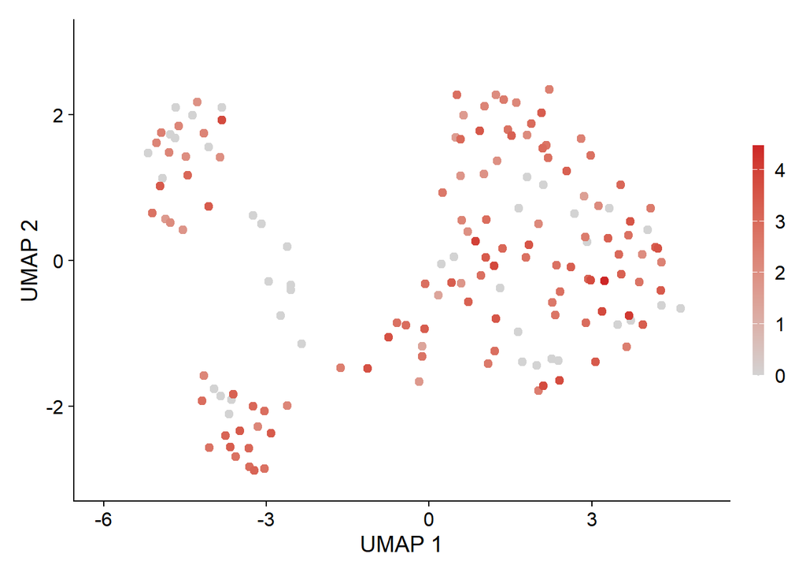

```
## [1] "prph"
```

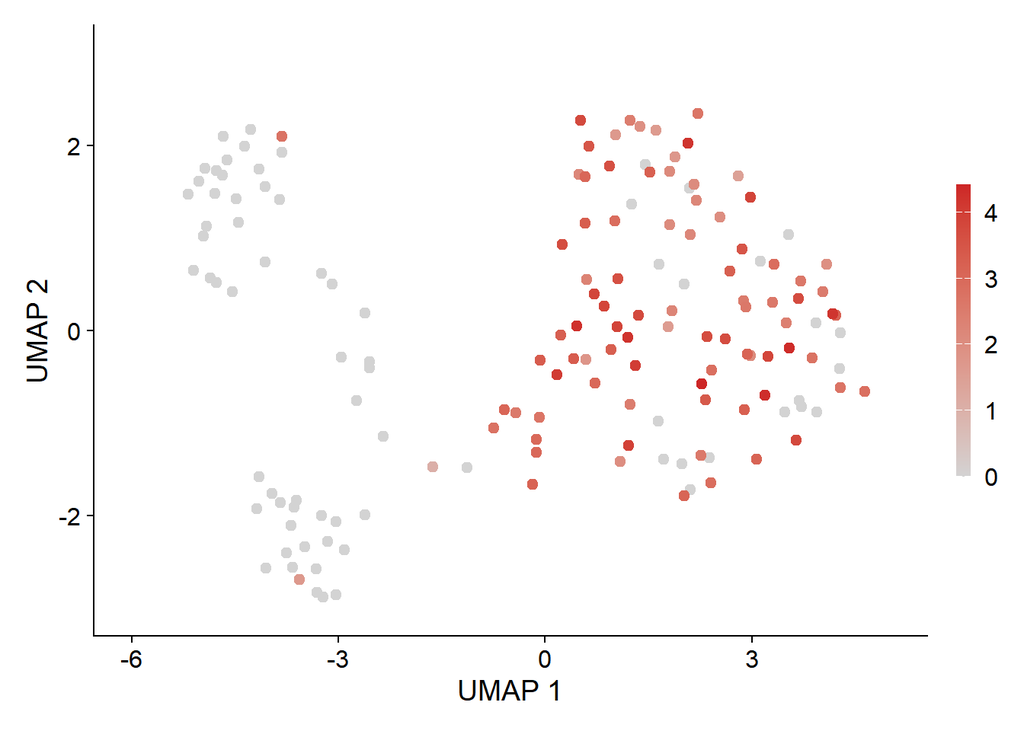

```
## [1] "sox11a"
```

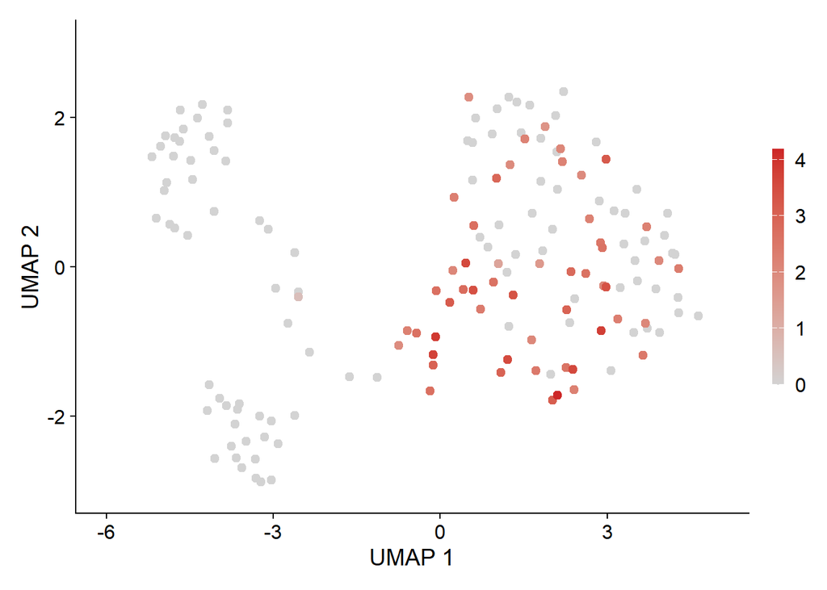

```
## [1] "rgs5a"
```

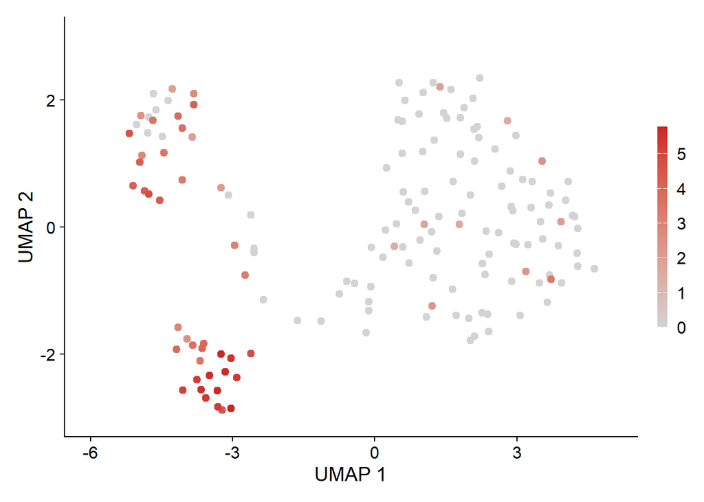

```
## [1] "ndufa4l2a"
```

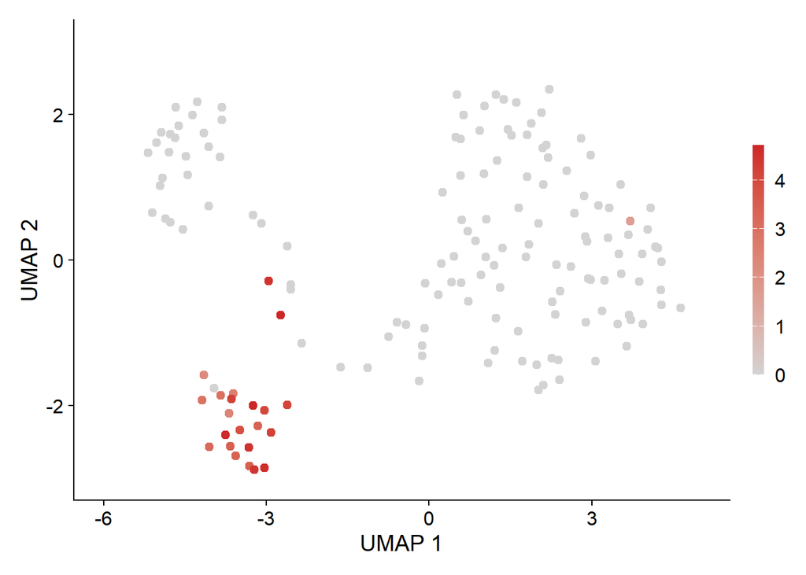

```
## [1] "dbh"
```

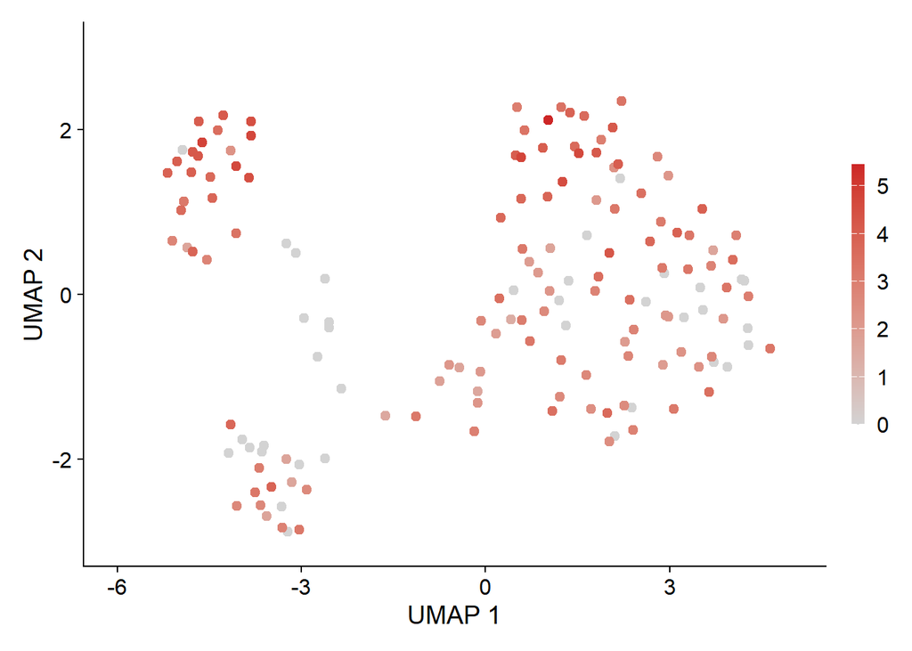

```
## [1] "epas1a"
```

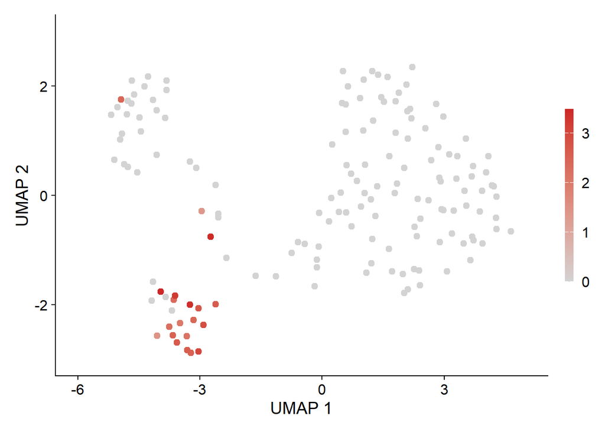

```
## [1] "slc6a3"
```

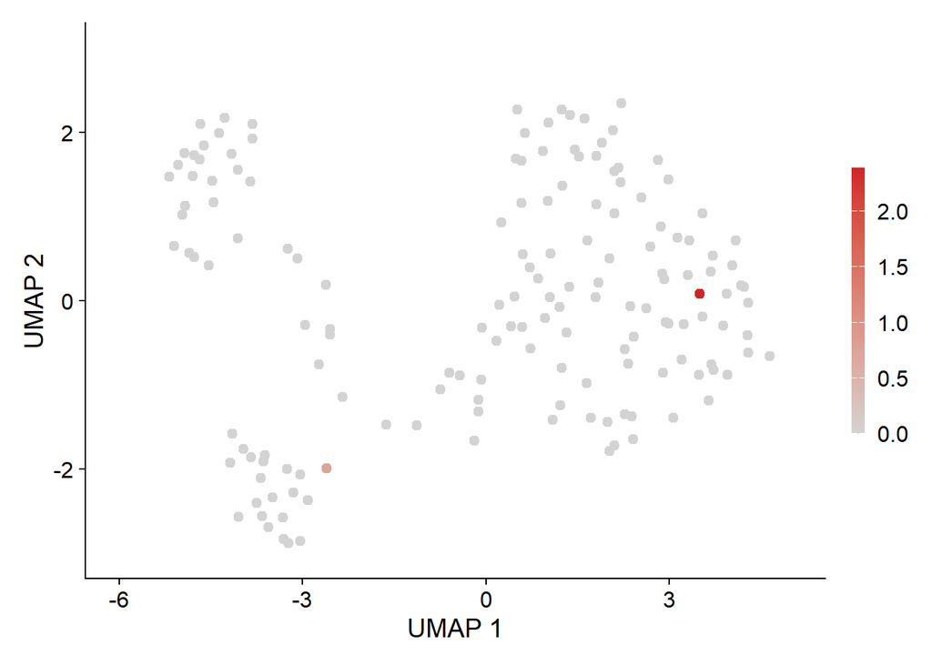

```
## [1] "slc6a2"
```

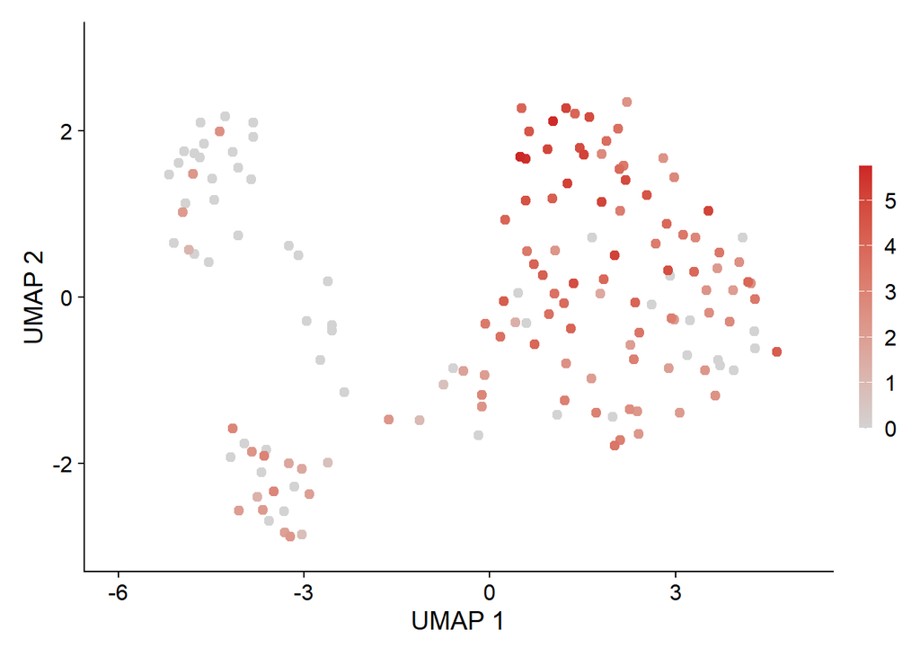

```
## [1] "tph1a"
```

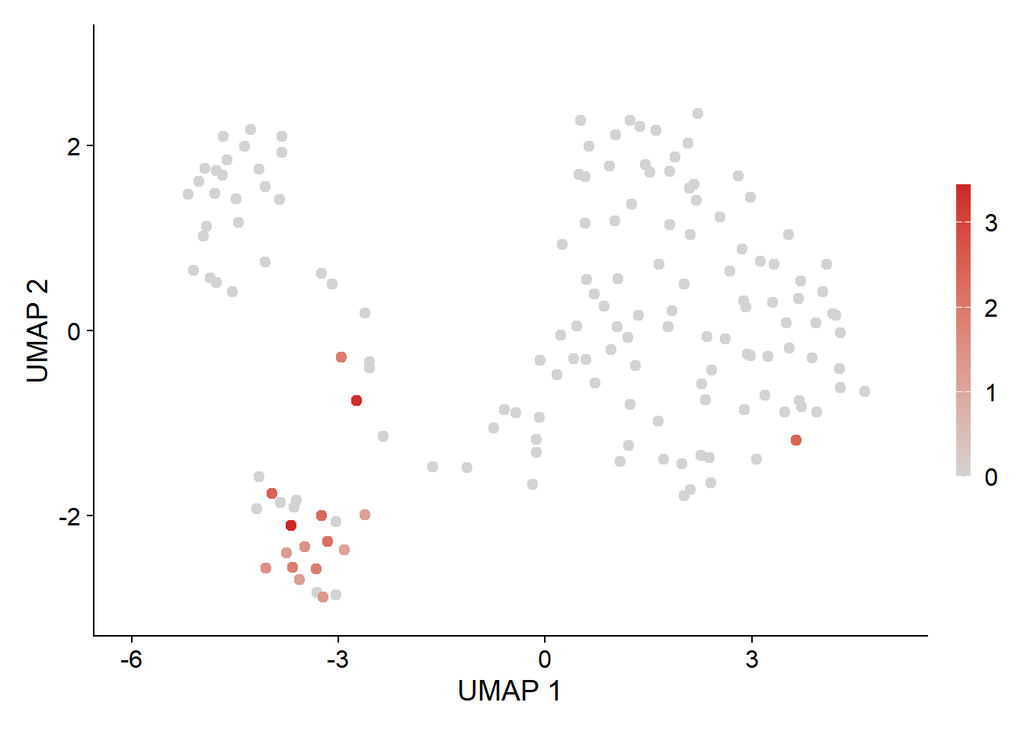

```
## [1] "th"
```

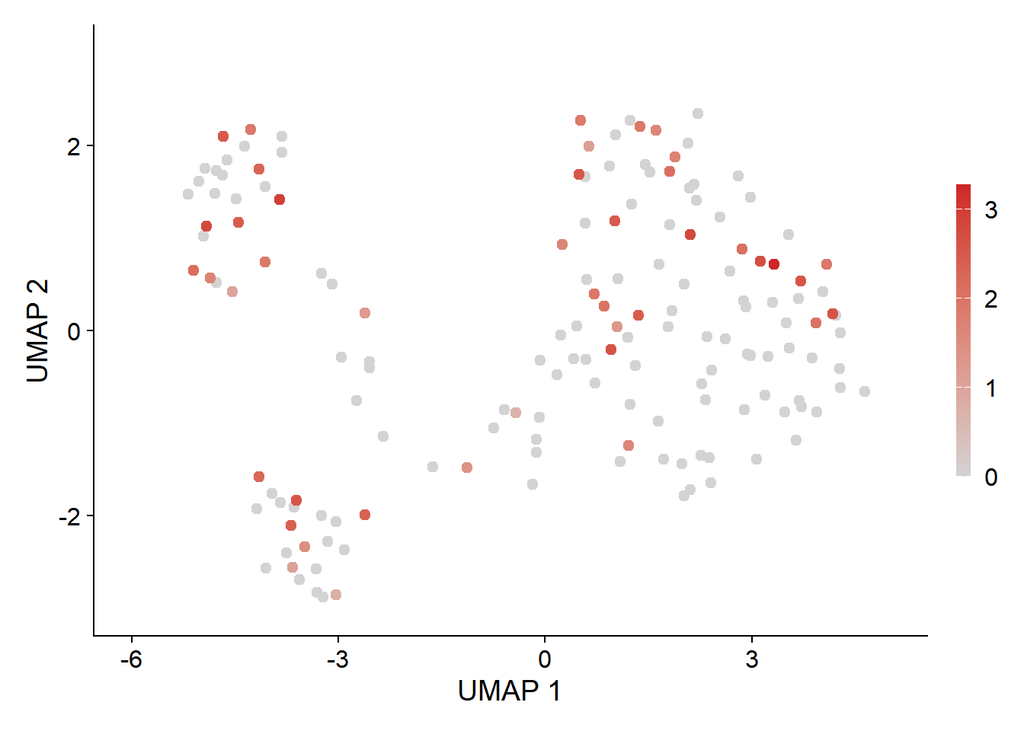

```r
genes <- c("hand2", "prph", "sox11a", "rgs5a", "ndufa4l2a","dbh", "epas1a", "slc6a3", "slc6a2", "tph1a", "th")

for (gene in genes) {
  plot <- FeaturePlot(Peripheral_subset, gene, pt.size = 2, order = T) +
    scale_colour_gradient(low="lightgrey", high="#cd2626") +
    labs(x = "UMAP 1", y = "UMAP 2", title = NULL) +
    guides(color = guide_colorbar(barwidth = 0.5, barheight = 10))
    plot_name <- paste("Script10_Fig4Supp_Peripheral_FeaturePlot_", gene,".svg", sep = "")
    print(gene)
    print(plot)
    ggsave(plot_name, plot = plot, path = "Figures/Figure4_Peripheral/",
           width = 5, height = 4)

}
```

```r
rm(list=ls())
gc()
```

```
##           used  (Mb) gc trigger  (Mb) max used  (Mb)
## Ncells 4062269 217.0    6894887 368.3  6894887 368.3
## Vcells 7194204  54.9   61234402 467.2 63718739 486.2
```